# GoBike Share Usage Pattern Analysis

## Investigation Overview

In this investigation, I will to look at the bike ride usage pattern in SanFrancisco Bay Area in Feb, 2019. The main focus was on biking duration on different time and user groups.

## Dataset Overview

This data set includes information about individual rides made in a bike-sharing system covering the greater San Francisco Bay area in Feb,2019. The data consisted of approximately 170K rows with attributes of user's profile (age,gender,subscription status, Bike Share all program enrollment status etc) and bike ride behavior (start/end station, bike ride duration,start/end time etc).

## Bike usage by Weekday

> First I will check out frequnecy of bike trips by day of wee to see when is the most busy day of week. Overall, the figure shows that the usages over weekdays are greater than over weekends(almost 1/3~1/2 of weekdays).Thursday was busiset day with highest counts of trips in this dataset.

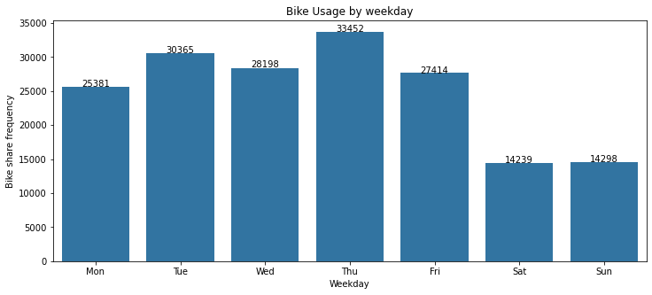

```python
base_color = sb.color_palette()[0]
bins=np.arange(7)
plt.figure(figsize=[12,5])
sb.countplot(data=df,x='weekday',color=base_color)

plt.xlabel('Weekday')
plt.ylabel('Bike share frequency')
plt.title('Bike Usage by weekday')

weekday_freq=df_clean.groupby('weekday').weekday.count()
for x,y in zip(bins,weekday_freq):
    label = "{}".format(y)
    plt.annotate(label, # this is the text
                 (x,y), # this is the point to label
                 textcoords="offset points", # how to position the text
                 xytext=(0,2), # distance from text to points (x,y)
                 ha='center') ;# horizontal alignment can be left, right or center
```

## Bike usage by Hour

> When I have plotted bike ride counts by hour, a bimodal curve with peaks at 8 AM and 5 PM was shown. This showed that bike trip frequency was highest around commuting time.

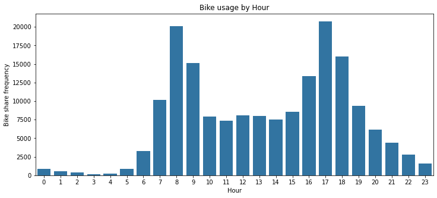

```python
base_color = sb.color_palette()[0]
plt.figure(figsize=[12,5])
#plt.xticks(range(24))
sb.countplot(data=df_clean,x='hour',color=base_color)
plt.xlabel('Hour')
plt.ylabel('Bike share frequency')
plt.title('Bike usage by Hour');
```

## Bike usage by Hour on weekdays and weekends

> When I have plotted hourly usage by day of weeks,I observed quite different bike ride patterns for weekdays and weekends. For weeknends single modal graph at peak around 2 pm was shown.

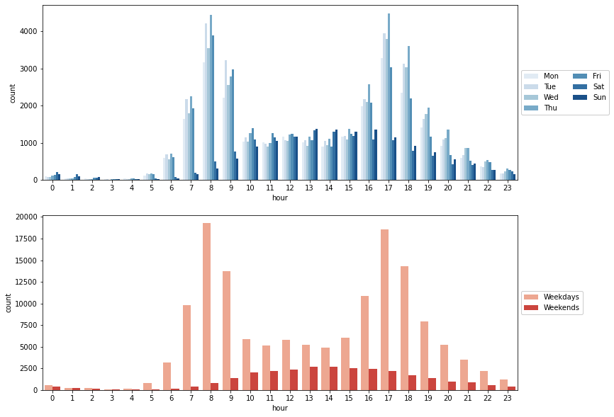

```python
plt.figure(figsize=[12,10])
#subplot 1: hourly usage on different day of week
plt.subplot(2, 1, 1)
sb.countplot(data = df_clean, x = 'hour', hue = 'weekday', palette = 'Blues');
plt.legend(framealpha = 1,bbox_to_anchor = (1, 0.5), loc = 6,ncol = 2);

#subplot 2: hourly usage on weekdays and weekends
ax = plt.subplot(2, 1, 2);
cat2_label=["Weekdays","Weekends"]
sb.countplot(data = df_clean, x = 'hour', hue = 'is_weekend', palette = 'Reds');
ax.legend(ncol = 2); # re-arrange legend to reduce overlapping
plt.legend(cat2_label, framealpha = 1,bbox_to_anchor = (1, 0.5),loc=6);
```

## Bike Ride Duration

> Next, I have investigated duration of bike trips. When I have plotted the histogram, I found that most of data lies under below 50 minutes(1 hr). The distribution is heavily skewed to the right showing that most bikes are generally used for short trips.

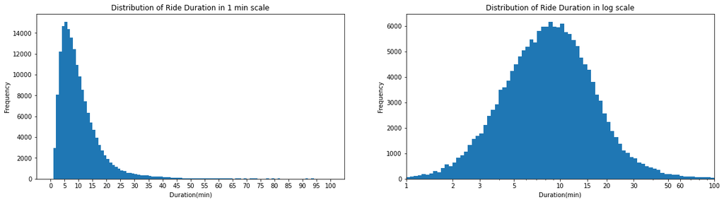

```python
#Define the Figure Size
plt.figure(figsize=[20,5])

#Bin size=1 min
plt.subplot(1, 2, 1)
bins=np.arange(0,100+1,1)
x_ticks=np.arange(0,100+5,5)
plt.hist(df.duration_min,bins=bins)
plt.xticks(x_ticks, x_ticks)
plt.xlabel('Duration(min)')
plt.ylabel('Frequency')
plt.title('Distribution of Ride Duration in 1 min scale')

#Bin size in log scale
plt.subplot(1, 2, 2)
log_binsize=0.025
bins = 10 ** np.arange(0, np.log10(df.duration_min.max())+log_binsize, log_binsize)
x_ticks=[1,2,3,5,10,15,20,30,50,60,100]
plt.hist(df.duration_min,bins=bins);
plt.xscale('log')
plt.xticks(x_ticks, x_ticks);
plt.xlabel('Duration(min)')
plt.ylabel('Frequency')
plt.title('Distribution of Ride Duration in log scale')
plt.xlim(1,100);
```

## Distance of Bike Trips

> Even if the start and end position cannot represent absolute travel distances, I have tried to plot histogram to see how far apart between the start and end bike stand. It seems that distance between start and end bike stations are under few kilimeters(~3 km) range. Distance of 0 or distance under few hundreds meters(~<200 meter) may represent round trips.

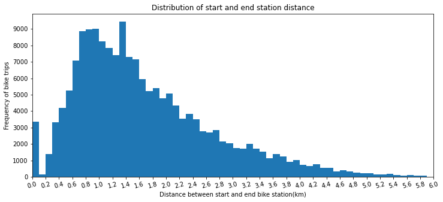

```python
plt.figure(figsize=[12,5])

bins=np.arange(0, df_clean.dist.max(), 0.1)
plt.hist(df_clean.dist,bins)
plt.xticks(np.around(np.arange(0,6+0.2,0.2),decimals=1),np.around(np.arange(0,6+0.2,0.2),decimals=1))
plt.xticks(rotation=15)
plt.yticks(np.arange(0,10000,1000),np.arange(0,10000,1000))
plt.xlabel('Distance between start and end bike station(km)')
plt.ylabel('Frequency of bike trips')
plt.title("Distribution of start and end station distance")
plt.xlim(0,6);
```

> Even though this is not exact measure (since actual travel distance would be different from direct distance & also there are round trip cases), we cloud roughly estimate riders' bike speed from the distance vs. Bike ride duratuion graph. With my rough estimation it was around 4 m/sec.

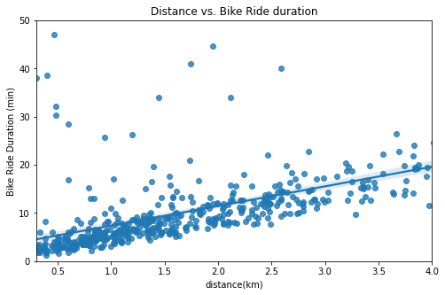

```python
df_ot=df_clean[df_clean['oneway_trip']==1]
df_ot.reset_index(drop=True,inplace=True)

plt.figure(figsize=[8,5]);

samples = np.random.choice(df_ot.shape[0], 500, replace = False)
samp = df_ot.loc[samples,:]

# scatter plot of duration_min vs. member_age, with log transform on duration_min axis

sb.regplot(data = samp, x = 'dist', y = 'duration_min');
plt.xlabel('distance(km)');
plt.ylim(0,50)
plt.xlim(0.3,4)
plt.ylabel('Bike Ride Duration (min)');
plt.title('Distance vs. Bike Ride duration');
```

## Distribution of the Age of Users

> Next, I have checked frequncy of bike share by different age groups. Since I have found that there were some unreasonable age groups(for example age >=90) I have limited my observation around 20s ~ 80s(exclusive). Most frequent trips were made by users of age between 30~40s(exclusive).

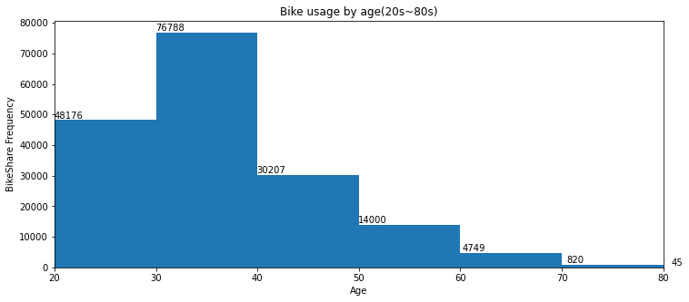

```python
bins=np.arange(df.age.min(), df.age.max()+10,10)
age_cat_values=pd.cut(df.age,bins,right=False,include_lowest=True)
values=df.groupby(age_cat_values).age.count()

plt.figure(figsize=[12,5])
plt.hist(data=df,x='age',bins=bins)
plt.ylabel('BikeShare Frequency')
plt.xlabel('Age')
plt.title('Bike usage by age(20s~80s)')



for x,y in zip(bins,values[:7]):

    label = "{}".format(y)

    plt.annotate(label, # this is the text
                 (x,y), # this is the point to label
                 textcoords="offset points", # how to position the text
                 xytext=(15,2), # distance from text to points (x,y)
                 ha='center') ;# horizontal alignment can be left, right or center
plt.xlim(20,80);
```

## Bike ride time pattern on different user age groups, hours and day of weeks

> When I have clustered rider group into two by their ages 1) Older than 40 yrs old and 2) less than equal 40 yrs and plotted bike ride duration vs. hour on every days of week, I have found that older group rides longer than younger group. Bike ride times were longer on Saturday and Sunday than weekdays. At around 2~5 AM, range of bike ride duration are widely distributed while the bike ride time is concentratd around 10 ~15 minutes.

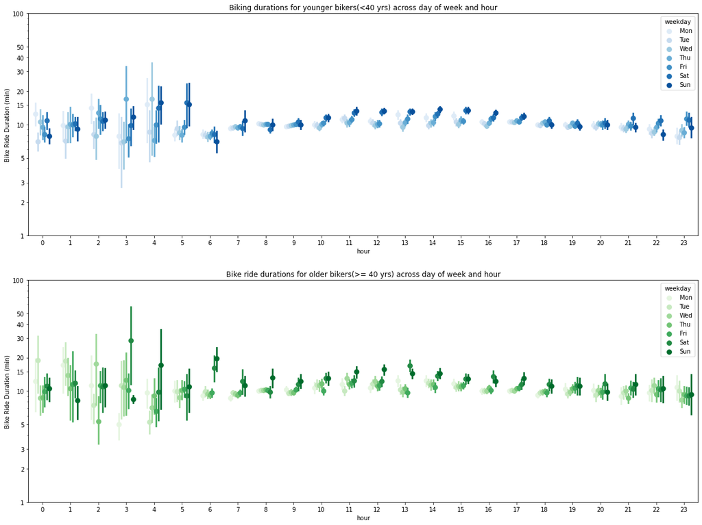

```python
fig = plt.figure(figsize = [20,15])

plt.subplot(2,1,1)
ax = sb.pointplot(data = df_clean[df_clean.age<40], x = 'hour', y = 'duration_min', hue = 'weekday',
           palette = 'Blues', linestyles = '', dodge = 0.5);

plt.title('Biking durations for younger bikers(<40 yrs) across day of week and hour');
plt.ylabel('Bike Ride Duration (min)');
plt.yscale('log');
plt.yticks([1, 2,3, 5, 10,15, 20,30, 40,50, 100], [1, 2,3, 5, 10,15, 20,30, 40,50, 100]);
ax.set_yticklabels([],minor = True);



plt.subplot(2,1,2)
ax = sb.pointplot(data = df_clean[df_clean.age>=40], x = 'hour', y = 'duration_min', hue = 'weekday',
           palette = 'Greens', linestyles = '', dodge = 0.5);

plt.title('Bike ride durations for older bikers(>= 40 yrs) across day of week and hour');
plt.ylabel('Bike Ride Duration (min)');
plt.yscale('log');
plt.yticks([1, 2,3, 5, 10,15, 20,30, 40,50, 100], [1, 2,3, 5, 10,15, 20,30, 40,50, 100]);
ax.set_yticklabels([],minor = True);
```

## Bike Usage by User Type

> Among all trips, 90.53% trips were made by subscribers.

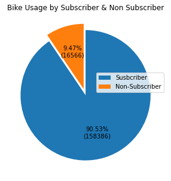

```python
plt.figure(figsize=[12,5])
x_label=['Susbcriber','Non-Subscriber']
explode = (0,0.1)

sorted_count=df['user_type'].value_counts()

plt.pie(sorted_count,labels=None,startangle=90, explode=explode,\
        autopct=lambda p:'{:.2f}%\n({:.0f})'.format(p,(p/100)*sorted_count.sum()),counterclock=False)

plt.title('Bike Usage by Subscriber & Non Subscriber')
plt.legend(x_label,bbox_to_anchor = (1, 0.5), loc = 4)
plt.axis('off');
```

> While overall trip numbers decrease during weekends, there was slight increase in proportion of usage by non-subscribers during weekends. This might be due to try out bike users for leisure purpose.

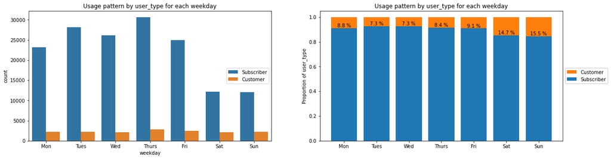

```python
plt.figure(figsize=[20,5])
plt.subplot(1,2,1)
cat1_label = ['Mon', 'Tues', 'Wed', 'Thurs','Fri','Sat','Sun']
cat2_label = ['Subscriber', 'Customer']
sb.countplot(data=df_clean,x='weekday',hue='user_type')
plt.xticks(np.arange(0,7),cat1_label)
plt.legend(cat2_label,loc=5);
plt.title("Usage pattern by user_type for each weekday")


plt.subplot(1,2,2)
bikes_count = []# for storing references to plot elements
baselines = np.zeros(len(cat1_label))
cat1_counts = df_clean.groupby('weekday')['weekday'].count()

for i in range(len(cat2_label)):
    cat2 = cat2_label[i]
    inner_counts = df_clean[df_clean['user_type'] == cat2].groupby('weekday')['weekday'].count()
    inner_props = inner_counts / cat1_counts
    bars = plt.bar(x = np.arange(len(cat1_label)),
                   height = inner_props,
                   bottom = baselines)

    bikes_count.append(bars)
    baselines += inner_props

plt.xticks(np.arange(len(cat1_label)), cat1_label)
plt.ylabel("Proportion of user_type")
plt.title("Usage pattern by user_type for each weekday")
plt.legend(reversed(bikes_count), reversed(cat2_label), framealpha = 1,
           bbox_to_anchor = (1, 0.5), loc = 6)
for x,y in zip(range(7),inner_props):
    label = "{:.1f} %".format(y*100)
    plt.annotate(label, # this is the text
                 (x,1-y), # this is the point to label
                 textcoords="offset points", # how to position the text
                 xytext=(0,2), # distance from text to points (x,y)
                 ha='center') ;# horizontal alignment can be left, right or cent
```

> Subscribers tends to take shorter trip than non-subscribers.

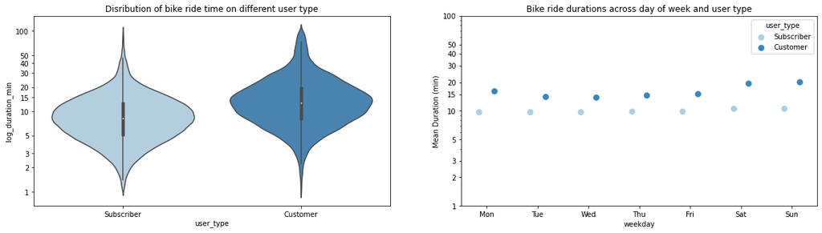

```python
fig = plt.figure(figsize = [20,5])
plt.subplot(1,2,1)
sb.violinplot(data = df_clean, x = 'user_type', y = 'log_duration_min',palette="Blues");
plt.yticks(log_trans(np.array([1, 2,3, 5, 10,15, 20,30, 40,50, 100])),[1, 2,3, 5, 10,15, 20,30, 40,50, 100]);
plt.title("Disribution of bike ride time on different user type")


plt.subplot(1,2,2)
ax = sb.pointplot(data = df_clean, x = 'weekday', y = 'duration_min', hue = 'user_type',
           palette = 'Blues', linestyles = '', dodge = 0.3);
plt.title('Bike ride durations across day of week and user type');
plt.ylabel('Mean Duration (min)')
plt.yscale('log');
plt.yticks([1, 2,3, 5, 10,15, 20,30, 40,50, 100], [1, 2,3, 5, 10,15, 20,30, 40,50, 100]);
ax.set_yticklabels([],minor = True);
```

## Bike Usage by Gender

> Most trips were made by Male users. Male trip count was roughly 3 times larger than female users.

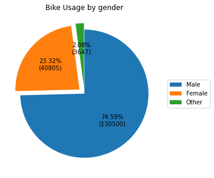

```python
plt.figure(figsize=[12,5])
x_label=['Male','Female','Other']
explode = (0,0.1,0.1)
sorted_count=df['member_gender'].value_counts()

plt.pie(sorted_count,labels=None,startangle=90, explode=explode,\
        autopct=lambda p:'{:.2f}%\n({:.0f})'.format(p,(p/100)*sorted_count.sum()),counterclock=False)

plt.title('Bike Usage by gender')
plt.legend(x_label,bbox_to_anchor = (1, 0.5), loc = 6)
plt.axis('off');
```

> Non-Subscriber portion of users are slightly higher in female than that of male.

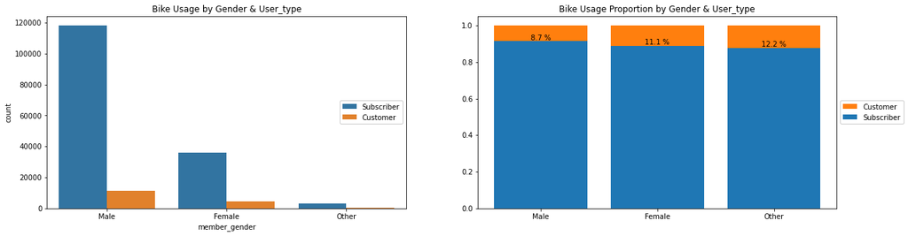

```python
plt.figure(figsize=[20,5])


plt.subplot(1,2,1)
cat1_order=["Male","Female","Other"]
cat2_order = ['Subscriber', 'Customer']
sb.countplot(data=df_clean,x='member_gender',hue='user_type')
plt.legend(framealpha = 1,bbox_to_anchor = (1, 0.5), loc = 5)
plt.title("Bike Usage by Gender & User_type")
##########################################

plt.subplot(1,2,2)
bikes_count = []# for storing references to plot elements
baselines = np.zeros(len(cat1_order))
cat1_counts = df_clean['member_gender'].value_counts()

for i in range(len(cat2_order)):
    cat2 = cat2_order[i]
    inner_counts = df_clean[df_clean['user_type'] == cat2]['member_gender'].value_counts()
    inner_props = inner_counts / cat1_counts
    bars = plt.bar(x = np.arange(len(cat1_order)),
                   height = inner_props,
                   bottom = baselines)

    bikes_count.append(bars)
    baselines += inner_props

plt.xticks(np.arange(len(cat1_order)), cat1_order)
plt.title("Bike Usage Proportion by Gender & User_type")
plt.legend(reversed(bikes_count), reversed(cat2_order), framealpha = 1,
           bbox_to_anchor = (1, 0.5), loc = 6)

for x,y in zip(range(3),inner_props):
    label = "{:.1f} %".format(y*100)
    plt.annotate(label, # this is the text
                 (x,1-y), # this is the point to label
                 textcoords="offset points", # how to position the text
                 xytext=(0,2), # distance from text to points (x,y)
                 ha='center') ;# horizontal alignment can be left, right or center;
```

## Bike Usage by bike_share_for_all_trip users

> "bike_share_fore_all_trip" column tracks members who are enrolled in the Bike Share for All program for low-income residents. Roughly about 10% of trips were made by Bike Share for All program enrolled users.

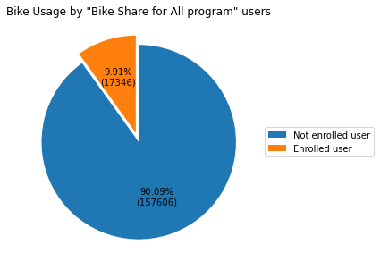

```python
plt.figure(figsize=[12,5])
x_label=['Not enrolled user','Enrolled user']
#x_order=['Yes','No']
explode = (0,0.1)

sorted_count=df['bike_share_for_all_trip'].value_counts()

plt.pie(sorted_count,labels=None,startangle=90, explode=explode,\
        autopct=lambda p:'{:.2f}%\n({:.0f})'.format(p,(p/100)*sorted_count.sum()),counterclock=False)

plt.title('Bike Usage by "Bike Share for All program" users')
plt.legend(x_label,bbox_to_anchor = (1, 0.5), loc = 6)
plt.axis('off');
```

> Bike Share for All program enrolled users are highly populated around under 30 years old. And they were younger than non-program users on average by ~5 years.

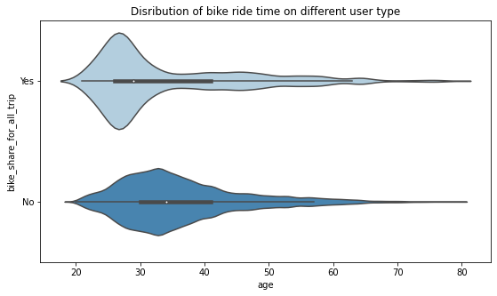

```python
# plot matrix of numeric features against categorical features.
# can use a larger sample since there are fewer plots and they're simpler in nature.

fig = plt.figure(figsize = [20,5])
plt.subplot(1,2,1)
sb.violinplot(data = df_clean, y = 'bike_share_for_all_trip', x = 'age',palette="Blues");
plt.title("Disribution of bike ride time on different user type");
```

> Bike Share for All program enrolled users take shorter trips than regular users on average.

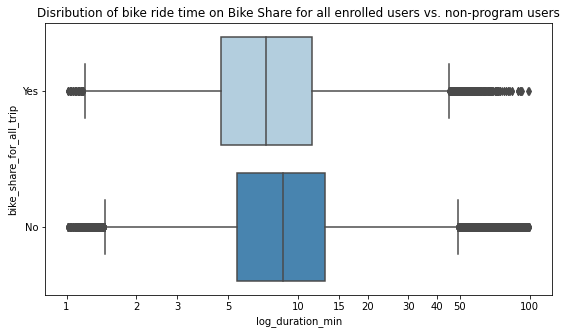

```python
fig = plt.figure(figsize = [20,5])
plt.subplot(1,2,1)
sb.boxplot(data = df_clean, y = 'bike_share_for_all_trip', x = 'log_duration_min',palette="Blues");
plt.xticks(log_trans(np.array([1, 2,3, 5, 10,15, 20,30, 40,50, 100])),[1, 2,3, 5, 10,15, 20,30, 40,50, 100]);
plt.title("Disribution of bike ride time on Bike Share for all enrolled users vs. non-program users");
```

> "Bike share for all" program enrolled users take shorter duration trips than non-program enrolled users in younger users. However, this is opposite in older users.

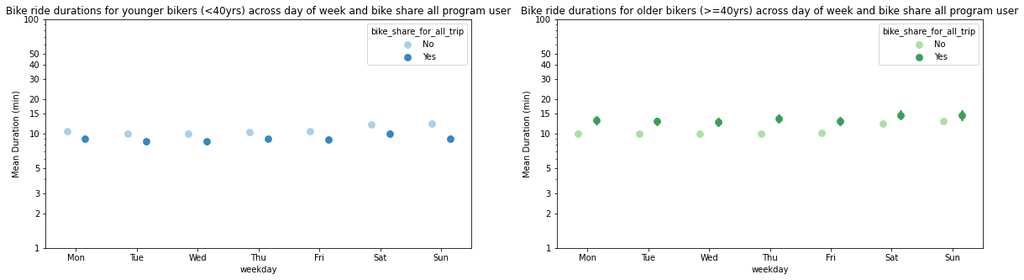

```python
fig = plt.figure(figsize = [20,5])
plt.subplot(1,2,1)

ax = sb.pointplot(data = df_clean[df_clean.age<40], x = 'weekday', y = 'duration_min', hue = 'bike_share_for_all_trip',
           palette = 'Blues', linestyles = '', dodge = 0.3);
plt.title('Bike ride durations for younger bikers (<40yrs) across day of week and bike share all program user');
plt.ylabel('Mean Duration (min)')
plt.yscale('log');
plt.yticks([1, 2,3, 5, 10,15, 20,30, 40,50, 100], [1, 2,3, 5, 10,15, 20,30, 40,50, 100]);
ax.set_yticklabels([],minor = True);

plt.subplot(1,2,2)

ax = sb.pointplot(data = df_clean[df_clean.age>=40], x = 'weekday', y = 'duration_min',
                  hue = 'bike_share_for_all_trip', hue_order=["No","Yes"],
           palette = 'Greens', linestyles = '', dodge = 0.3);
plt.title('Bike ride durations for older bikers (>=40yrs) across day of week and bike share all program user');
plt.ylabel('Mean Duration (min)')
plt.yscale('log');
plt.yticks([1, 2,3, 5, 10,15, 20,30, 40,50, 100], [1, 2,3, 5, 10,15, 20,30, 40,50, 100]);
ax.set_yticklabels([],minor = True);
```